# PADP8120_Homework1

Fall 2015 - Key

# Homework 1

Guidelines: Homeworks should be clear and legible, with answers clearly indicated and work shown. Homeworks will be given a minus, check, or check plus owing to completion and correctness. You are welcome to work with others but please submit your own work. Your homework must be produced in an R Markdown (.rmd) file submitted via github. If you are having trouble accomplishing this, please refer to the [guide](http://spia.uga.edu/faculty_pages/tyler.scott/teaching/PADP8120_Fall2015/Homeworks/submitting_homework.shtml). This homework is adapted from the work of Jenny Bryan (http://www.stat.ubc.ca/~jenny/STAT545A/current.html)

Topics covered in this homework include:

- Data manipulation and exploration in R
- Making a document in R Markdown
- Version control

(the last two elements will be covered by the fact that you are required to produce your homework in R Markdown and submit it via github)

The goal is to manipulate and explore a dataset with the `dplyr` package, complemented by visualizations made with `ggplot2`. In particular, we keep our focus on working with a `data.frame` (but note: `dplyr` can work with other data storage formats seamlessly). Your homework should serve as your own personal cheatsheet in the future for ways to manipulate a dataset and produce companion figures. Give yourself the cheatsheet you deserve!

## Part A - Load gapminder data

Work with the [Gapminder excerpt](http://www.stat.ubc.ca/~jenny/notOcto/STAT545A/examples/gapminder/data/gapminderDataFiveYear.txt) maintained by Jenny Bryan at UBC (i.e., the first part of this task will be to figure out how to load these data). Import the data with `read.delim()` and with `read.table()`. FYI: `read.delim()` is just a wrapper around `read.table()` with specific arguments set to certain values. [Read the documentation!](http://www.rdocumentation.org/packages/utils/functions/read.table)

- Load the Gapminder data with both functions without specifying args other than `file`. Do you get the same resulting object in your workspace? Use all the ways we’ve learned to inspect an object to back up your claims with hard facts.

```r
#read.table fails
gapminder.data = read.table(file='http://tiny.cc/gapminder')
```

```
## Error in scan(file, what, nmax, sep, dec, quote, skip, nlines, na.strings, : line 146 did not have 6 elements
```

```r
#read.delim works as well, it's better at guessing
gapminder.data = read.delim(file='http://tiny.cc/gapminder')
```

- If you’re not getting the same object, why not?

Read.table seems to be choking on the 146 line. Since read.delim works fine, we can look at the 146 row and quess as to why. It looks like it’s struggling to guess because Bosnia and Herzeogvina is a long name.

```r
gapminder.data[146,]
```

```
##                    country year     pop continent lifeExp gdpPercap
## 146 Bosnia and Herzegovina 1957 3076000    Europe   58.45  1353.989
```

- Develop the call to `read.table()` that is equivalent to `read.delim()`, i.e. how do you need to set various arguments and describe this in prose as well.

```r
#read.table works when we specify the delimiter
gapminder.data = read.table(file='http://tiny.cc/gapminder',sep='\t',header=T)
```

When we specify the separater with the `sep` option, `read.table` now works just fine. The difference is that `read.table` does not necessarily expect a delimited file, whereas `read.delim` guesses that the file is a `.csv` (comma delimited) or `txt` (tab delimited) file automatically. Note that I also specified `header=T` so that R knows that the first row has column names (i.e., variable names) and not just another row of observations.

One issue: take a look at how `read.table` seems to choke on ’Cote d’Ivoire:

```r
gapminder.data[grep('Cote',gapminder.data$country),]
```

```
##                                                                     country
## 361  Cote dIvoire\t1952\t2977019\tAfrica\t40.477\t1388.594732\nCote dIvoire
## 362   Cote dIvoire\t1962\t3832408\tAfrica\t44.93\t1728.869428\nCote dIvoire
## 363  Cote dIvoire\t1972\t6071696\tAfrica\t49.801\t2378.201111\nCote dIvoire
## 364  Cote dIvoire\t1982\t9025951\tAfrica\t53.983\t2602.710169\nCote dIvoire
## 365 Cote dIvoire\t1992\t12772596\tAfrica\t52.044\t1648.073791\nCote dIvoire
## 366 Cote dIvoire\t2002\t16252726\tAfrica\t46.832\t1648.800823\nCote dIvoire
##     year      pop continent lifeExp gdpPercap
## 361 1957  3300000    Africa  42.469  1500.896
## 362 1967  4744870    Africa  47.350  2052.050
## 363 1977  7459574    Africa  52.374  2517.737
## 364 1987 10761098    Africa  54.655  2156.956
## 365 1997 14625967    Africa  47.991  1786.265
## 366 2007 18013409    Africa  48.328  1544.750
```

It doesn’t handle the extra apostrophe well. So, let’s use the `read.delim` approach instead.

```r
#read.table works when we specify the delimiter
gapminder.data = read.delim(file='http://tiny.cc/gapminder',sep='\t',header=T)
gapminder.data[grep('Cote',gapminder.data$country),]
```

```
##           country year      pop continent lifeExp gdpPercap
## 361 Cote d'Ivoire 1952  2977019    Africa  40.477  1388.595
## 362 Cote d'Ivoire 1957  3300000    Africa  42.469  1500.896
## 363 Cote d'Ivoire 1962  3832408    Africa  44.930  1728.869
## 364 Cote d'Ivoire 1967  4744870    Africa  47.350  2052.050
## 365 Cote d'Ivoire 1972  6071696    Africa  49.801  2378.201
## 366 Cote d'Ivoire 1977  7459574    Africa  52.374  2517.737
## 367 Cote d'Ivoire 1982  9025951    Africa  53.983  2602.710
## 368 Cote d'Ivoire 1987 10761098    Africa  54.655  2156.956
## 369 Cote d'Ivoire 1992 12772596    Africa  52.044  1648.074
## 370 Cote d'Ivoire 1997 14625967    Africa  47.991  1786.265
## 371 Cote d'Ivoire 2002 16252726    Africa  46.832  1648.801
## 372 Cote d'Ivoire 2007 18013409    Africa  48.328  1544.750
```

Good to go!

## Part B - Data smell test

Explore your new data.frame.

- Is it a data.frame, a matrix, a vector, a list?

```r
class(gapminder.data)
```

```
## [1] "data.frame"
```

Yes, it is a data.frame object.

- What’s its mode, class?

```r
str(gapminder.data)
```

```
## 'data.frame':    1704 obs. of  6 variables:
##  $ country  : Factor w/ 142 levels "Afghanistan",..: 1 1 1 1 1 1 1 1 1 1 ...
##  $ year     : int  1952 1957 1962 1967 1972 1977 1982 1987 1992 1997 ...
##  $ pop      : num  8425333 9240934 10267083 11537966 13079460 ...
##  $ continent: Factor w/ 5 levels "Africa","Americas",..: 3 3 3 3 3 3 3 3 3 3 ...
##  $ lifeExp  : num  28.8 30.3 32 34 36.1 ...
##  $ gdpPercap: num  779 821 853 836 740 ...
```

- How many variables?

As the above output shows, the data frame has 6 variables.

- How many rows/observations?

- Can you get these facts about “extent” or “size” in more than one way? Can you imagine different functions being useful in different contexts?

There are a **ton** of ways to get this info. Among them, we can use the `dim`/`ncol`/`nrow` family.

## Part C - Explore individual variables

Pick **at least** one categorical variable and at least one quantitiative variable to explore.

- Characterize what’s possible, i.e. all possible values or max vs. min … whatever’s appropriate.

The categorical variable I pick is `continent`. To see what the different possible values are, I will use the `unique` function to show all unique category values:

```r
unique(gapminder.data$continent)
```

```
## [1] Asia     Europe   Africa   Americas Oceania
## Levels: Africa Americas Asia Europe Oceania
```

The numeric variable I pick is gdpPercap. To view the maximum and minimum values, I use the `max` and `min` functions:

```r
max(gapminder.data$gdpPercap)
```

```
## [1] 113523.1
```

```r
min(gapminder.data$gdpPercap)
```

```
## [1] 241.1659
```

- What’s typical? What’s the spread? What’s the distribution? Etc., tailored to the variable at hand.

For the `continent` variable, we can view the distribution of values using the `table` function:

```r
table(gapminder.data$continent)
```

```
##
##   Africa Americas     Asia   Europe  Oceania
##      624      300      396      360       24
```

To view a typical value for *gdpPercap*, the summary command shows the mean and median values. It also shows the spread and gives an idea of the distribution by showing the quartile values. In particular, we can see that the variable has a long tail on the right, since the max is much, much higher than the 75% quartile.

```r
summary(gapminder.data$gdpPercap)
```

```
##     Min.  1st Qu.   Median     Mean  3rd Qu.     Max.
##    241.2   1202.0   3532.0   7215.0   9325.0 113500.0
```

- Feel free to use summary stats, tables, figures. Don’t worry about high production values.

We can also view this distribution using the `hist` plot commmand:

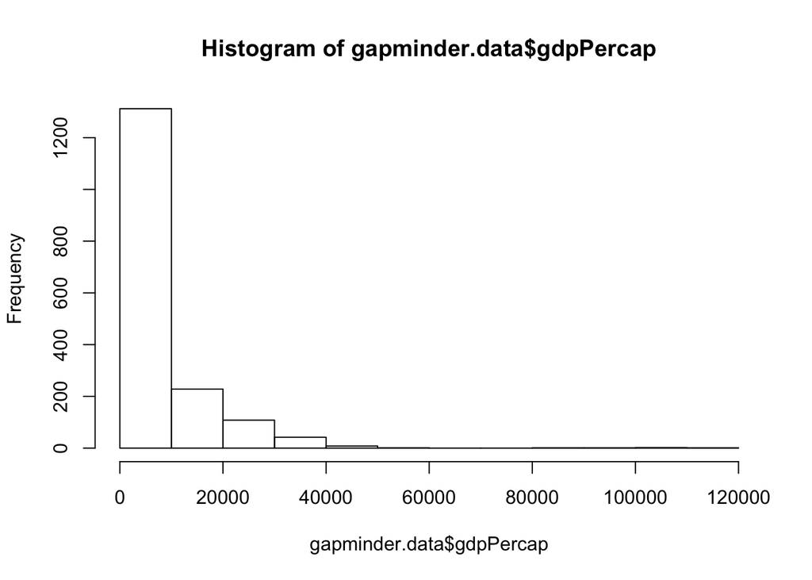

```r
hist(gapminder.data$gdpPercap)
```

## Part D - Getting down to business

Attack each of the tasks below with a table and figure.

- Base R tools (e.g., `subset`, logicals) and `dplyr` should be your main data manipulation tools
- `ggplot2` should be your main visualization tool

Make observations about what your tables/figures show and about the process.

If you want to do something comparable but different, i.e. swap one quantitative variable for another, be my guest! If you are feeling inspired and curious, then we’re doing this right. Go for it.

Relax about the following things:

- Tidying/reshaping is NOT your assignment. Many of your tables will be awkwardly shaped in the report. That’s OK.
- Table beauty is not a big deal. Simply printing to “screen” is fine. You could also try the `knitr::kable()` function. Assuming `my_df` is a data.frame, here’s an R chunk that should print it as a decent-looking table:

````
```{r results = 'asis'}
knitr::kable(my_df)
```
````

- For all things, graphical and tabular, if you’re dissatisfied with a result, discuss the problem, what you’ve tried and move on.

### Task menu

1. Get the maximum and minimum of GDP per capita for all continents.

```r
#note: setting message = FALSE in the chunk settings simply sets the chunk so that the rendered markdown document won't show all of those extra package loading messages that typically show up in red text
library(dplyr);library(knitr)
#without kable function; note that I names the output variables "min" and "max" - you could call those whatever you want
gapminder.data %>% group_by(continent) %>% summarise(min = min(gdpPercap),max = max(gdpPercap))
```

```
## Source: local data frame [5 x 3]
##
##   continent        min       max
## 1    Africa   241.1659  21951.21
## 2  Americas  1201.6372  42951.65
## 3      Asia   331.0000 113523.13
## 4    Europe   973.5332  49357.19
## 5   Oceania 10039.5956  34435.37
```

```r
#with kable function
kable(gapminder.data %>% group_by(continent) %>% summarise(min = min(gdpPercap),max = max(gdpPercap)))
```

| continent | min | max |
| --- | --- | --- |
| Africa | 241.1659 | 21951.21 |
| Americas | 1201.6372 | 42951.65 |
| Asia | 331.0000 | 113523.13 |
| Europe | 973.5332 | 49357.19 |
| Oceania | 10039.5956 | 34435.37 |

2. Look at the spread of GDP per capita within the continents.

```r
gapminder.data %>% group_by(continent) %>% summarise(min = min(gdpPercap), max = max(gdpPercap),range = max - min)
```

```
## Source: local data frame [5 x 4]
##
##   continent        min       max     range
## 1    Africa   241.1659  21951.21  21710.05
## 2  Americas  1201.6372  42951.65  41750.02
## 3      Asia   331.0000 113523.13 113192.13
## 4    Europe   973.5332  49357.19  48383.66
## 5   Oceania 10039.5956  34435.37  24395.77
```

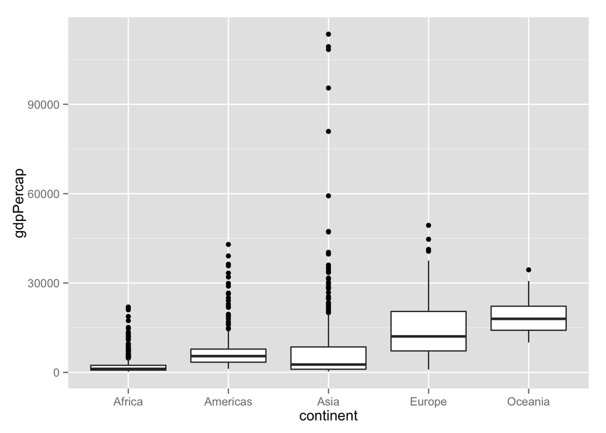

```r
library(ggplot2)
ggplot(data = gapminder.data,aes(group=continent,y=gdpPercap,x=continent)) + geom_boxplot()
```

3. Compute a trimmed mean of life expectancy for different years. Or a weighted mean, weighting by population. Just try something other than the plain vanilla mean.

```r
#trim = 0.05 drops the top and bottom 5% (i.e., drop 10% of the data in total - in real life, this is probably too much)
gapminder.data %>% group_by(year) %>% summarise(trimmed.mean = mean(lifeExp,trim=0.05))
```

```
## Source: local data frame [12 x 2]
##
##    year trimmed.mean
## 1  1952     48.84636
## 2  1957     51.41927
## 3  1962     53.63838
## 4  1967     55.80484
## 5  1972     57.85226
## 6  1977     59.88981
## 7  1982     61.85009
## 8  1987     63.60734
## 9  1992     64.80741
## 10 1997     65.56467
## 11 2002     66.19818
## 12 2007     67.56459
```

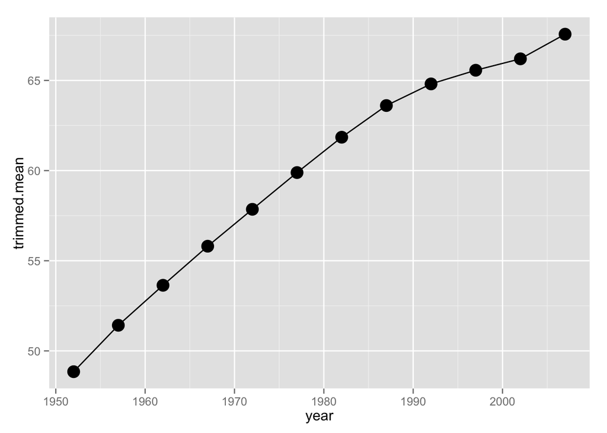

```r
trimmed.lifexp.means.by.year <- gapminder.data %>% group_by(year) %>% summarise(trimmed.mean = mean(lifeExp,trim=0.05))
ggplot(data=trimmed.lifexp.means.by.year) + geom_path(aes(x=year,y=trimmed.mean)) + geom_point(aes(x=year,y=trimmed.mean),size=5)
```

4. How is life expectancy changing over time on different continents?

```r
library(tidyr)
mean.lifeExp.longfile = gapminder.data %>% group_by(continent,year) %>% summarise(mean = mean(lifeExp))
#spread function from tidyr package makes it easy to go from long file to wide file or vice-versa
#note that I round mean to 2 digits so it prints nicely
mean.lifeExp.longfile %>% mutate(mean = round(mean,2)) %>% spread(year,mean)
```

```
## Source: local data frame [5 x 13]
##
##   continent  1952  1957  1962  1967  1972  1977  1982  1987  1992  1997
## 1    Africa 39.14 41.27 43.32 45.33 47.45 49.58 51.59 53.34 53.63 53.60
## 2  Americas 53.28 55.96 58.40 60.41 62.39 64.39 66.23 68.09 69.57 71.15
## 3      Asia 46.31 49.32 51.56 54.66 57.32 59.61 62.62 64.85 66.54 68.02
## 4    Europe 64.41 66.70 68.54 69.74 70.78 71.94 72.81 73.64 74.44 75.51
## 5   Oceania 69.25 70.30 71.09 71.31 71.91 72.85 74.29 75.32 76.94 78.19
## Variables not shown: 2002 (dbl), 2007 (dbl)
```

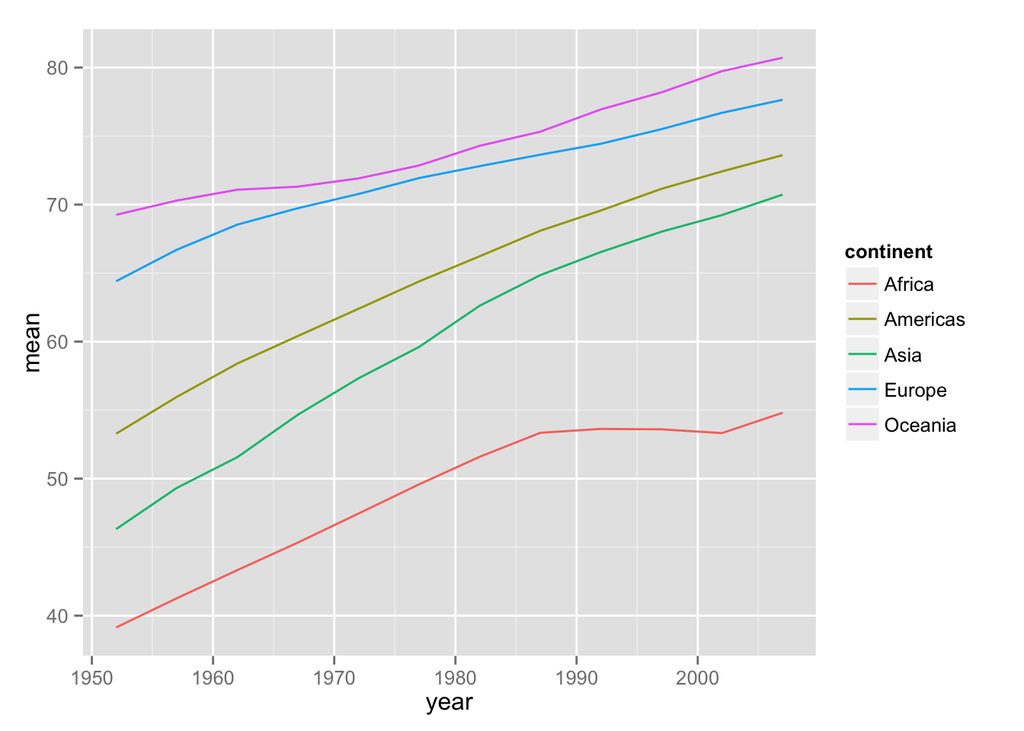

```r
lifexp.mean.by.year.continent <- gapminder.data %>% group_by(continent,year) %>% summarise(mean = mean(lifeExp))
ggplot(data=lifexp.mean.by.year.continent) + geom_line(aes(x=year,y=mean,color=continent))
```

5. Report the absolute and/or relative abundance of countries with low life expectancy over time by continent: Compute some measure of worldwide life expectancy – you decide – a mean or median or some other quantile or perhaps your current age. The determine how many countries on each continent have a life expectancy less than this benchmark, for each year.

I think that a reasonable way to specify low-life expectancy would be to a country that is at least 1 standard deviation below the mean for that year.

```r
#new.table <- old.table %>% grouped by year %>% calculate mean for year, sd for year, and then if value is less than mean - sd, code as 1, otherwise 0

life.exp.table <- gapminder.data %>% group_by(year) %>% mutate(year.mean = mean(lifeExp),year.sd = sd(lifeExp),low.lifeExp = ifelse(lifeExp < year.mean - year.sd,1,0))

#now, if we take the mean of the variable low.lifeExp for each continent and year, we'll have the proportion of countries that have a low lifeExp (as I have defined it) for each continent/year pairing:

low.lifeExp.by.continent = life.exp.table %>% group_by(continent,year) %>% summarise(prop.low.lifeExp = round(mean(low.lifeExp),2))

#now, use spread to make nice table format (key = what you want to turn into column headings, value = cell values)
low.lifeExp.by.continent %>% spread(key = year, value = prop.low.lifeExp)
```

```
## Source: local data frame [5 x 13]
##
##   continent 1952 1957 1962 1967 1972 1977 1982 1987 1992 1997 2002 2007
## 1    Africa 0.33 0.37 0.42 0.44 0.48 0.46 0.50 0.54 0.52 0.56 0.60 0.58
## 2  Americas 0.00 0.00 0.00 0.00 0.00 0.00 0.00 0.00 0.00 0.00 0.00 0.00
## 3      Asia 0.12 0.09 0.12 0.12 0.15 0.15 0.12 0.06 0.03 0.03 0.03 0.03
## 4    Europe 0.00 0.00 0.00 0.00 0.00 0.00 0.00 0.00 0.00 0.00 0.00 0.00
## 5   Oceania 0.00 0.00 0.00 0.00 0.00 0.00 0.00 0.00 0.00 0.00 0.00 0.00
```

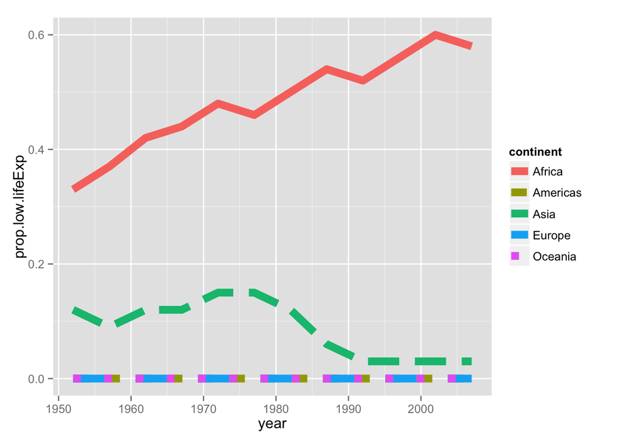

```r
ggplot(data = low.lifeExp.by.continent,aes(x=year,y=prop.low.lifeExp)) + geom_line(aes(color=continent,lty=continent),size=3)
```

6. Find countries with interesting stories. Open-ended and, therefore, hard. Promising but unsuccessful attempts are encouraged. This will generate interesting questions to follow up on in class.

Looking only at the most recent data from 2007, I plot GDP per-capita against life expentancy. There appears to be diminishing returns associated with national GDP. That is, there is clearly a positive relationship between GDP per capita and life expectancy, but this relationship diminishes as GDP per capita increases. In other words, after a certain point (what looks like about 25k-30k GDP per-capita), an increase in GDP per-capita does not seem to be associated with an increase in life expectancy.

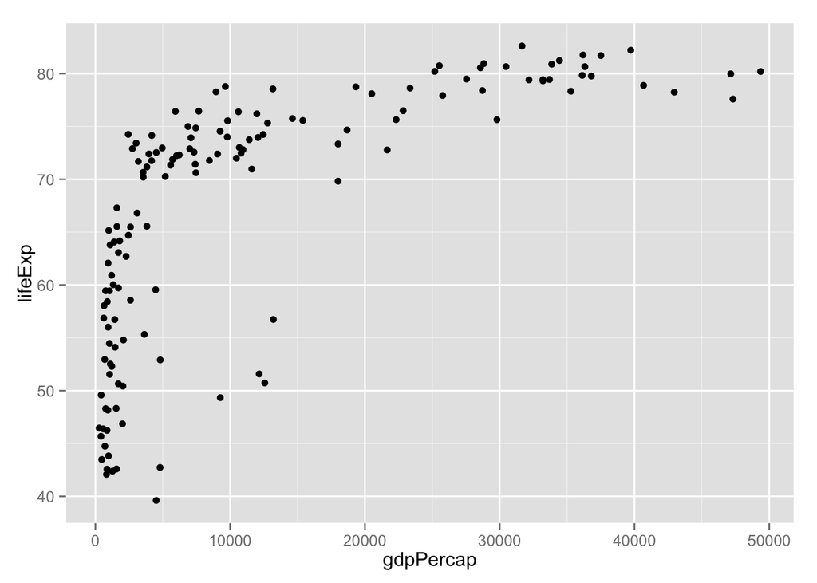

```r
ggplot(gapminder.data[gapminder.data$year==2007,],aes(x=gdpPercap,y=lifeExp)) + geom_point(aes(label=country))
```

In looking at the figure above, it’s also apparent that there are a few countries that seem to significantly underperform in terms of life expectancy based upon GDP per-capita. To take a look, I filter for countries with GDP per-capita less than 20k, and plot the country name labels:

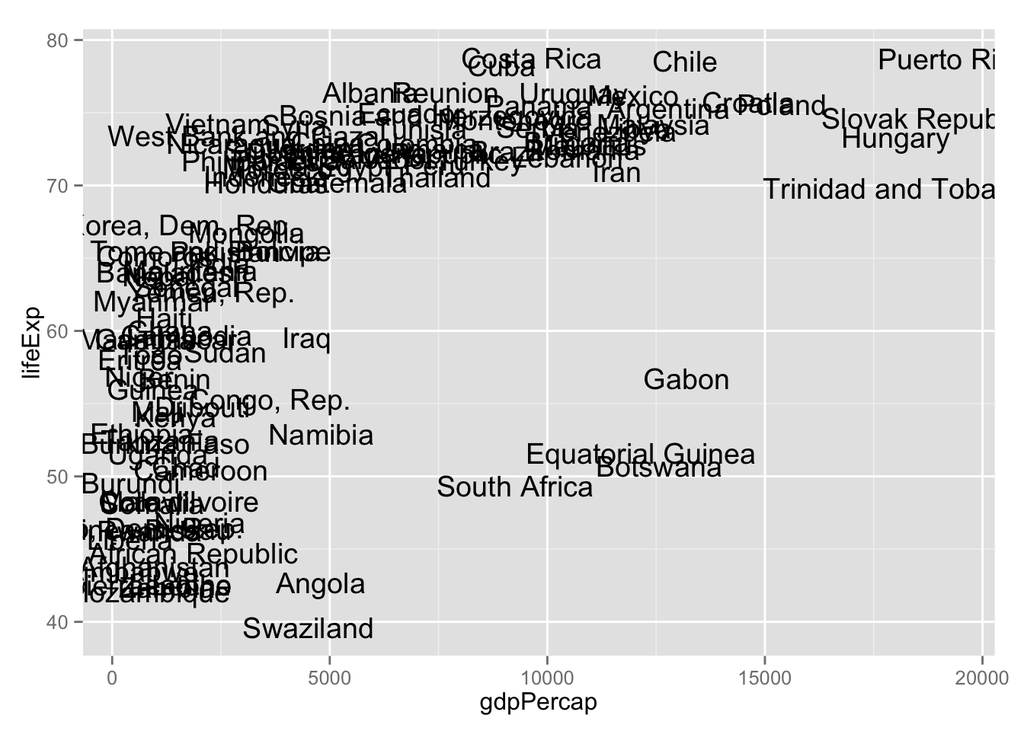

```r
ggplot(gapminder.data[gapminder.data$year==2007&gapminder.data$gdpPercap<20000,],aes(x=gdpPercap,y=lifeExp)) + geom_text(aes(label=country))
```

It looks like Gabon, South Africa, Equatorial Guinea, and Botswana have particularly low life expectancy given their GDP. I’m not certain why this would be the case for these countries, but perhaps AIDS is a driving factor.

### Companion graphs

For each table, make sure to include a relevant figure.

Your figure does not have to depict every last number from the data aggregation result. Use your judgement. It just needs to complement the table, add context, and allow for some sanity checking both ways.

Notice which figures are easy/hard to make, which data formats make better inputs for plotting functions vs. for human-friendly tables.

### Report your process

You’re encouraged to reflect on what was hard/easy, problems you solved, helpful tutorials you read, etc. Give credit to your sources, whether it’s a blog post, a fellow student, an online tutorial, etc.

### Submit the assignment

Follow instructions on How to submit homework

### Rubric

Minus: Didn’t tackle at least 3 tasks. Or didn’t make companion graphs. Didn’t interpret anything but left it all to the “reader”. Or more than one technical problem that is relatively easy to fix. It’s hard to find the report in our repo.

Check: Completed, but not fully accurate and/or readable. Requires a bit of detective work on my part to see what you did

Check plus: Hits all the elements. No obvious mistakes. Pleasant to read. No heroic detective work required. Solid.

Overachiever! (no extra credit, but you will recieve my admiration): Exceeded the requirements in number of tasks. Or developed novel tasks that were indeed interesting and “worked”. Impressive use of `dplyr` and/or `ggplot2`. Impeccable organization of repo and report. You learned something new from reviewing their work and you’re eager to incorporate it into your work.